# Building Programs With Python

26/03/2018

## Etherpad

Please do use the course Etherpad:

- http://pad.software-carpentry.org/2018-03-29-standrews
- **Communal notes**: share your understanding, and benefit from others
- **Ask questions**: get detailed answers with links and examples
- **A record/reference for after the course**

## Why Are We Here?

- **To learn basic concepts of programming** (in Python)
- **How to solve problems in your research by…**
  - Building scripts
  - Automating tasks
- **Mechanics of manipulating data**
  - File I/O
  - Data structures

## XKCD

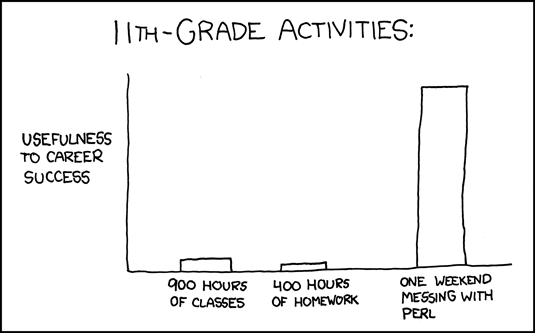

## How Are We Doing This?

**Using the `Python` language**

- we need *something* ;)
- free, well-documented, and cross-platform
- large academic userbase
- many *libraries* for specialist work

**we won’t be covering the entire language**

## No, I mean “*how* are we doing this?”

**Text editor**

- the more usual way to write code
- edit-save-execute cycle

**`Jupyter` notebook**

- interactive notebook-based interface
- good for data exploration, prototyping, and teaching
- not so good for writing scripts/‘production code’

## Do I need to use `Python` afterwards?

- No. ;)
  - The lesson is general, it’s just taught in `Python`
  - The principles are the same in nearly all languages
  - If your colleagues/field settled on another language(s), maybe learn that
  - (language wars are unproductive… ;) )

## What are we doing?

**Analysing and visualising experimental data**

- Effectiveness of a new treatment for arthritis
- Several patients, recording inflammation on each day
- Tabular (comma-separated) data

**We’re going to get the computer to do this for us**

- Why not just do it by hand?
- **AUTOMATION**, **REUSE**, **SHARING**

## 01. Setup

## Setting Up - 1

Before we begin…

- **make a neat working environment in the terminal**
- obtain data

```bash
cd ~/Desktop
mkdir python-novice-inflammation
cd python-novice-inflammation
```

**LIVE DEMO**

## Setting up - 2

Before we begin…

- make a neat working environment
- **obtain data**

```bash
cp 2018-03-29-standrews/lessons/python/files/python-novice-inflammation-data.zip ./
unzip python-novice-inflammation-data.zip
cp 2018-03-29-standrews/lessons/python/files/python-novice-inflammation-code.zip ./
unzip python-novice-inflammation-code.zip
```

(you can download files via [`Etherpad`](http://pad.software-carpentry.org/2018-03-29-standrews): http://pad.software-carpentry.org/2018-03-29-standrews)

**LIVE DEMO**

## 02. Getting Started

## `Python` in the terminal

We start the `Python` console by executing the command `python`

```bash
$ python
Python 3.6.3 |Anaconda custom (64-bit)| (default, Oct  6 2017, 12:04:38)
[GCC 4.2.1 Compatible Clang 4.0.1 (tags/RELEASE_401/final)] on darwin
Type "help", "copyright", "credits" or "license" for more information.
>>>
```

**LIVE DEMO**

## `Python` REPL

- `Python`’s **console** is a *read-evaluate-print-loop*, just like the shell

```python
>>> 3 + 5
8
>>> 12 / 7
1.7142857142857142
>>> 2 ** 16
65536
>>> 15 % 4
3
>>> (2 + 4) * (3 - 7)
-24
```

**LIVE DEMO**

## My first variable

- To do interesting things, we want *persistent* values
- variables are like *named boxes*
- data goes in the box
- when we use the name of the box, we mean **what’s in the box**

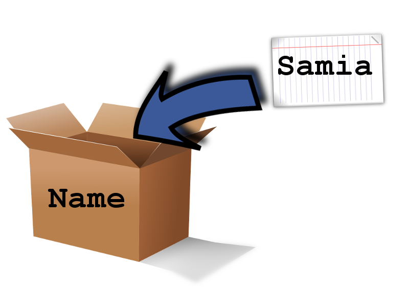

## Creating a variable

- To *assign* a value use the *equals sign*: `=`
- The variable name/box label goes on the left, and the data item goes on the right
- *Character strings*, or just *strings*, are enclosed in quotes

```python
>>> name = "Samia"
>>> name
'Samia'
>>> print(name)
Samia
```

**LIVE DEMO**

## Working with variables

```python
weight_kg = 55
print(weight_kg)
2.2 * weight_kg
print("weight in pounds", 2.2 * weight_kg)
weight_kg = 57.5
print("weight in kilograms is now:", weight_kg)
weight_lb = 2.2 * weight_kg
print('weight in kilograms:', weight_kg, 'and in pounds:', weight_lb)
weight_kg = 100
print('weight in kilograms:', weight_kg, 'and in pounds:', weight_lb)
```

**LIVE DEMO**

## Exercise 01 (5min)

What are the values in `mass` and `age` after the following code is executed?

```python
mass = 47.5
age = 122
mass = mass * 2.0
age = age - 20
```

1. `mass == 47.5`, `age == 122`
2. `mass == 95.0`, `age == 102`
3. `mass == 47.5`, `age == 102`
4. `mass == 95.0`, `age == 122`

## Exercise 02 (5min)

What does the following code print out?

```python
first, second = 'Grace', 'Hopper'
third, fourth = second, first
print(third, fourth)
```

1. `Hopper Grace`
2. `Grace Hopper`
3. `"Grace Hopper"`
4. `"Hopper Grace"`

## 03. Data Analysis

## Examine the data

- Inspect a data file using the shell

```bash
$ head data/inflammation-01.csv
0,0,1,3,1,2,4,7,8,3,3,3,10,5,7,4,7,7,12,18,6,13,11,11,7,7,4,6,8,8,4,4,5,7,3,4,2,3,0,0
0,1,2,1,2,1,3,2,2,6,10,11,5,9,4,4,7,16,8,6,18,4,12,5,12,7,11,5,11,3,3,5,4,4,5,5,1,1,0,1
0,1,1,3,3,2,6,2,5,9,5,7,4,5,4,15,5,11,9,10,19,14,12,17,7,12,11,7,4,2,10,5,4,2,2,3,2,2,1,1
0,0,2,0,4,2,2,1,6,7,10,7,9,13,8,8,15,10,10,7,17,4,4,7,6,15,6,4,9,11,3,5,6,3,3,4,2,3,2,1
0,1,1,3,3,1,3,5,2,4,4,7,6,5,3,10,8,10,6,17,9,14,9,7,13,9,12,6,7,7,9,6,3,2,2,4,2,0,1,1
0,0,1,2,2,4,2,1,6,4,7,6,6,9,9,15,4,16,18,12,12,5,18,9,5,3,10,3,12,7,8,4,7,3,5,4,4,3,2,1
0,0,2,2,4,2,2,5,5,8,6,5,11,9,4,13,5,12,10,6,9,17,15,8,9,3,13,7,8,2,8,8,4,2,3,5,4,1,1,1
0,0,1,2,3,1,2,3,5,3,7,8,8,5,10,9,15,11,18,19,20,8,5,13,15,10,6,10,6,7,4,9,3,5,2,5,3,2,2,1
0,0,0,3,1,5,6,5,5,8,2,4,11,12,10,11,9,10,17,11,6,16,12,6,8,14,6,13,10,11,4,6,4,7,6,3,2,1,0,0
0,1,1,2,1,3,5,3,5,8,6,8,12,5,13,6,13,8,16,8,18,15,16,14,12,7,3,8,9,11,2,5,4,5,1,4,1,2,0,0
```

- To load this data in `Python`, we’ll use the `numpy` *library*

**We want to produce summary information about inflammation by patient and by day**

## `Python` libraries

- `Python` contains many powerful, general tools
- Specialised tools are contained in *libraries* or *packages*
- We call on libraries/packages, when needed
- Packages are loaded with `import`
- Packages are shared via repositories, e.g. [`PyPI`](https://pypi.python.org/pypi) and [`conda`](https://conda.io/docs/)

```python
>>> import numpy
```

**LIVE DEMO**

## Load data from file

- `numpy` provides a function `loadtxt()` to load tabular data:

```python
numpy.loadtxt(fname='data/inflammation-01.csv', delimiter=',')
```

- *dotted notation* tells us `loadtxt()` belongs to `numpy`
- `fname`: an *argument* expecting the path to a file
- `delimiter`: an *argument* expecting the character that separates columns

## Loaded data

```python
>>> numpy.loadtxt(fname='data/inflammation-01.csv', delimiter=',')
array([[ 0.,  0.,  1., ...,  3.,  0.,  0.],
       [ 0.,  1.,  2., ...,  1.,  0.,  1.],
       [ 0.,  1.,  1., ...,  2.,  1.,  1.],
       ...,
       [ 0.,  1.,  1., ...,  1.,  1.,  1.],
       [ 0.,  0.,  0., ...,  0.,  2.,  0.],
       [ 0.,  0.,  1., ...,  1.,  1.,  0.]])
```

- The matrix is truncated to fit the screen
- `...` indicate missing rows or columns
- If there are no significant digits, they are not shown (`1 == 1. == 1.0`)

**Assign the matrix to a variable called `data`**

**LIVE DEMO**

## What is our data?

```python
>>> type(data)
<class 'numpy.ndarray'>
```

**LIVE DEMO**

## Members and attributes

- Creating the array created information, too
- Info stored in *members* or *attributes* that belong to `data`
- `data.<attribute>` e.g. `data.shape`

```python
>>> print(data.dtype)
float64
>>> print(data.shape)
(60, 40)
```

**LIVE DEMO**

## Indexing arrays

- We often work with subsets of data
  - individual rows (patients)
  - individual columns (days)
- Counting of array elements **starts at zero**, not at one.

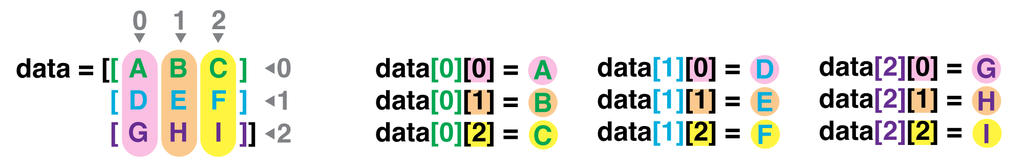

```python
>>> print('first value in data:', data[0, 0])
first value in data: 0.0
>>> print('middle value in data:', data[30, 20])
middle value in data: 13.0
```

**LIVE DEMO**

## Slicing arrays

- To get a *range* of data from the array, index with `[` and specify *start* and *end* indices
- `0:4` means **start at zero** and go up to **but not including** 4
  - `0, 1, 2, 3`
- Define *start* and *end* separated by `:` (colon).

```python
>>> print(data[0:4, 0:10])
[[ 0.  0.  1.  3.  1.  2.  4.  7.  8.  3.]
 [ 0.  1.  2.  1.  2.  1.  3.  2.  2.  6.]
 [ 0.  1.  1.  3.  3.  2.  6.  2.  5.  9.]
 [ 0.  0.  2.  0.  4.  2.  2.  1.  6.  7.]]
```

**LIVE DEMO**

## More slices, please!

- Don’t specify *start*, `Python` assumes the first element
- Don’t specify *end*, `Python` assumes the end element

```python
>>> small = data[:3, 36:]
>>> print('small is:\n', small)
```

**QUESTION:** What would `:` on its own indicate?

**LIVE DEMO**

## Exercise 03 (5min)

We can take slices of any series, not just arrays.

```python
>>> element = 'oxygen'
>>> print('first three characters:', element[0:3])
first three characters: oxy
```

What is the value of `element[:4]`?

1. `oxyg`
2. `gen`
3. `oxy`
4. `en`

## Array operations

- `array`s know how to perform operations on their values
- `+`, `-`, `*`, `/`, etc. are *elementwise*

```python
>>> doubledata = data * 2.0
>>> print("original:\n", data[:3, 36:])
original:
 [[ 2.  3.  0.  0.]
 [ 1.  1.  0.  1.]
 [ 2.  2.  1.  1.]]
>>> print("doubledata:\n", doubledata[:3, 36:])
doubledata:
 [[ 4.  6.  0.  0.]
 [ 2.  2.  0.  2.]
 [ 4.  4.  2.  2.]]
```

**LIVE DEMO**

## `numpy` functions

- `numpy` provides functions to operate on arrays

```python
>>> print(numpy.mean(data))
6.14875
>>> print(data.mean())
6.14875
>>> maxval = numpy.max(data)
>>> print('maximum inflammation:', maxval)
maximum inflammation: 20.0
>>> minval = data.min()
>>> print('minimum inflammation:', minval)
minimum inflammation: 0.0
```

- By default, these give summaries of the whole array.

**LIVE DEMO**

## Summary for one patient

- We want to summarise inflammation *by patient*

Extract a single row, or operate directly on a row

```python
>>> patient_0 = data[0, :] # temporary variable
>>> print('maximum inflammation for patient 0:', patient_0.max())
maximum inflammation for patient 0: 18.0
>>> print('maximum inflammation for patient 0:', numpy.max(data[0, :]))
maximum inflammation for patient 0: 18.0
>>> print('maximum inflammation for patient 2:', numpy.max(data[2, :]))
maximum inflammation for patient 2: 19.0
```

**LIVE DEMO**

## Summary for all patients

- What if we need maximum inflammation for *each patient* or average inflammation on *each day*?
- One line per patient/per day?

**Tedious. Prone to errors/typos**: easier way to to do this…

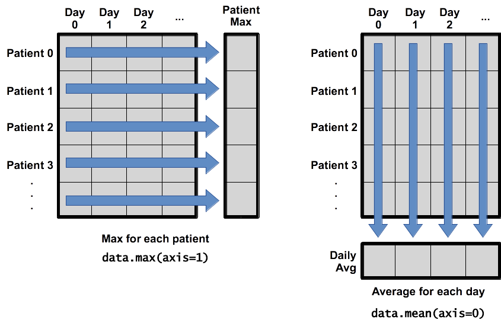

## `numpy` operations on axes

- `numpy` functions take an `axis=` parameter: `0` (columns) or `1` (rows)

```python
>>> print(numpy.max(data, axis=1))    # max by patient
[ 18.  18.  19.  17.  17.  18.  17.  20.  17.  18.  18.  18.  17.  16.  17.
  18.  19.  19.  17.  19.  19.  16.  17.  15.  17.  17.  18.  17.  20.  17.
  16.  19.  15.  15.  19.  17.  16.  17.  19.  16.  18.  19.  16.  19.  18.
  16.  19.  15.  16.  18.  14.  20.  17.  15.  17.  16.  17.  19.  18.  18.]
>>> print(data.mean(axis=0))          # mean by day
[  0.           0.45         1.11666667   1.75         2.43333333   3.15
   3.8          3.88333333   5.23333333   5.51666667   5.95         5.9
   8.35         7.73333333   8.36666667   9.5          9.58333333
  10.63333333  11.56666667  12.35        13.25        11.96666667
  11.03333333  10.16666667  10.           8.66666667   9.15         7.25
   7.33333333   6.58333333   6.06666667   5.95         5.11666667   3.6
   3.3          3.56666667   2.48333333   1.5          1.13333333
   0.56666667]
```

**LIVE DEMO**

## 04. Visualisation

## Visualisation

> “The purpose of computing is insight, not numbers” - Richard Hamming

The best way to gain insight is often to visualise data

- Visualisation deserves a course to itself
- Here’s one I prepared earlier (for the [Software Sustainability Institute](https://www.software.ac.uk/)):

[figure not shown]

- [Research Data Visualisation Workshop](https://widdowquinn.github.io/Teaching-Data-Visualisation/)

## Graphics package: `matplotlib`

`matplotlib` is the *de facto* standard/base plotting library in `Python`

```python
>>> import matplotlib.pyplot
```

**LIVE DEMO**

## `matplotlib.pyplot.imshow()`

`matplotlib.pyplot.imshow()` renders matrix values as an image

```python
>>> image = matplotlib.pyplot.imshow(data)
>>> matplotlib.pyplot.show()
```

- small values are dark blue, large values are yellow
- inflammation rises and falls over a 40-day period

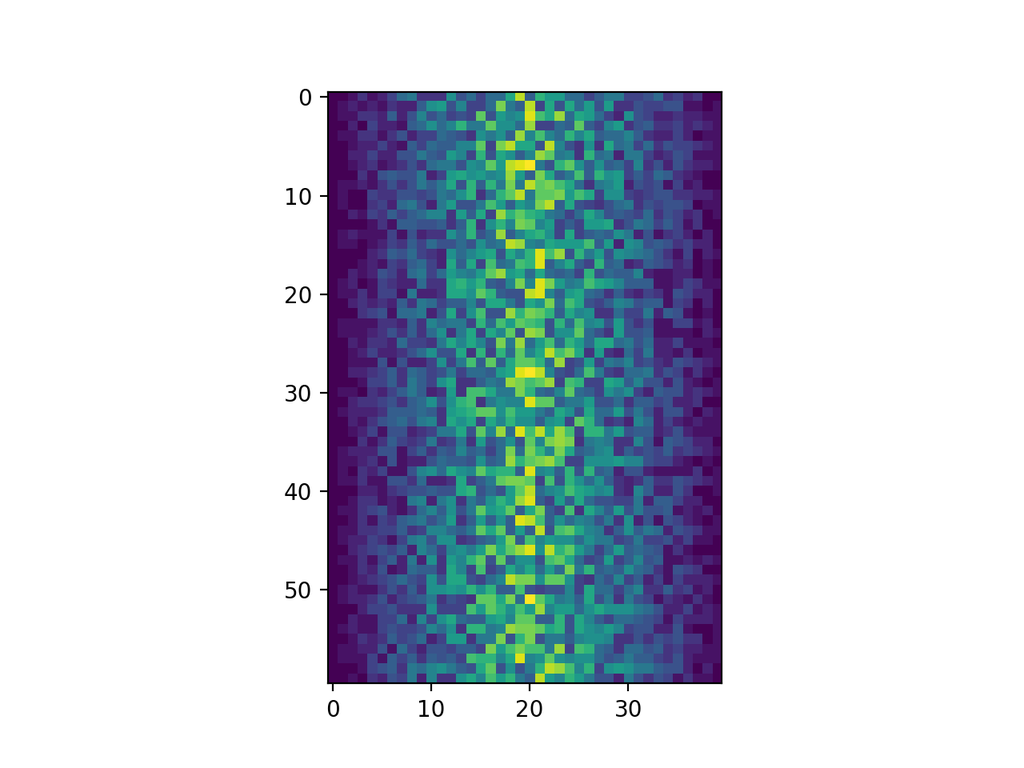

## `matplotlib.pyplot.plot()`

- `matplotlib.pyplot.plot()` renders a line graph

We want to plot the average inflammation level on each day

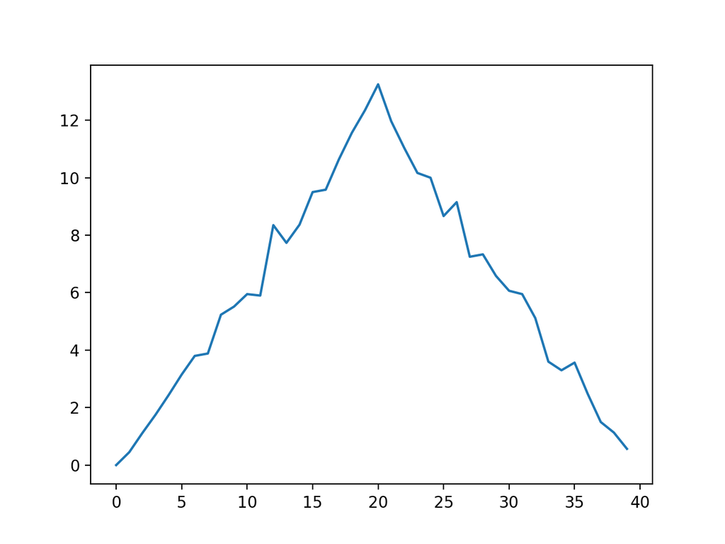

```python
>>> ave_inflammation = numpy.mean(data, axis=0)
>>> ave_plot = matplotlib.pyplot.plot(ave_inflammation)
>>> matplotlib.pyplot.show()
```

**QUESTION: does this look reasonable?**

## Investigating data

- The plot of `.mean()` looks artificial
- Look at other statistics to gain insight

```python
>>> max_plot = matplotlib.pyplot.plot(numpy.max(data, axis=0))
>>> matplotlib.pyplot.show()
>>> min_plot = matplotlib.pyplot.plot(numpy.min(data, axis=0))
>>> matplotlib.pyplot.show()
```

**QUESTION: does this look reasonable?**

## Exercise 04 (5min)

Can you create a plot showing the standard deviation (`numpy.std()`) of the inflammation data for each day across all patients?

## Figures and subplots

We can put all three plots into a single *figure*

- create a *figure* (`fig`) with `fig = matplotlib.pyplot.figure()`
- add subplots to `fig` with `ax = fig.add_subplot()`
- set labels on a subplot with `ax.set_ylabel()`
- plot data to a subplot with `ax.plot()`

**LIVE DEMO**

## Exercise 05 (5min)

Can you modify your script to display the three graphs on top of one another, instead of side by side?

**Save your new script as `exercise_05.py`**

## 05. `for` loops

## Motivation

- We wrote some code that plots values of interest from a single dataset

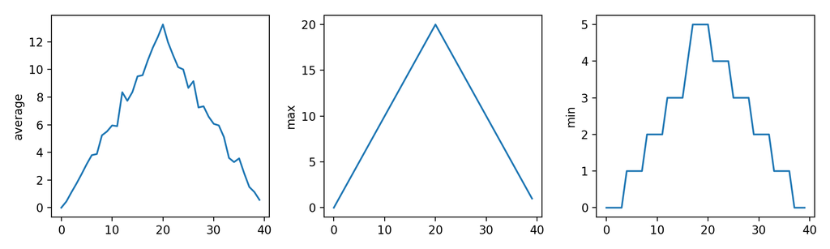

- **BUT** we’re soon going to receive *dozens* of datasets to plot
- So we need to make the computer *iterate* over the data

**`for` loops**

## Spelling Bee

- Suppose we wanted to spell a word, one letter at a time

```python
word = "lead"
print(word[0])
print(word[1])
print(word[2])
print(word[3])
```

**QUESTION:** Why is this not a good approach?

**LIVE DEMO**

## `for` loops

- `for` loops perform actions *for* every item *in* a collection

```python
>>> word = "lead"
>>> for char in word:
...     print(char)
...
l
e
a
d
```

**LIVE DEMO**

## `for` loop syntax

```python
for element in collection:
    <do things with element>
```

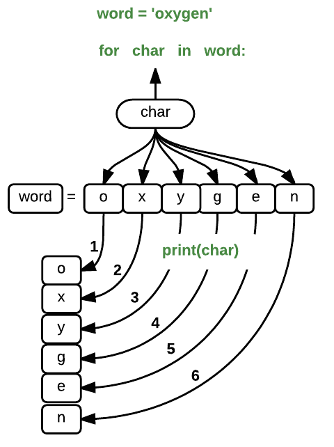

## Counting with a `for` loop

Values defined outside a loop can be modified in the loop

```python
>>> length = 0
>>> for vowel in 'aeiou':
...     length = length + 1
...
>>> print("There are", length, "vowels")
```

**QUESTION:** What output does this program give you?

**LIVE DEMO**

## `for` loop variables

- The *loop variable* is updated on each cycle
- It keeps its value when the loop is finished

```python
>>> letter = "z"
>>> print(letter)
z
>>> for letter in "abc":
...     print(letter)
...
>>> print("after the loop, letter is:", letter)
```

**LIVE DEMO**

## `range()`

`range()` is a `Python` function that creates a sequence of numbers

- It returns a `range` type that can be iterated over in a loop

```python
>>> seq = range(3)
>>> print("Range is:", seq)
>>> for val in seq:
...     print(val)
>>> seq = range(2, 5)
>>> seq = range(3, 10, 3)
>>> seq = range(10, 0, -1)
```

**LIVE DEMO**

## Exercise 06 (5min)

Can you write a loop that takes a string, e.g. `Newton`, and produces a new string with the characters in reverse order, e.g. `notweN`?

**HINTS**

1. You can “add” strings, e.g. `ab` + `cd`
2. An *empty string* can be created with `mystr = ""`

## 06. `list`s

## Lists

- `list`s are a built in `Python` datatype
- Denoted by square brackets, comma-separated
  - *iterable* lists of values
  - indexed and sliced like arrays

```python
>>> odds = [1, 3, 5, 7]
>>> print("odds are:", odds)
odds are: [1, 3, 5, 7]
>>> print('first and last:', odds[0], odds[-1])
first and last: 1 7
>>> for number in odds:
...     print(number)
```

**LIVE DEMO**

## Mutability

- `list`s, like `string`s, are sequences
- **BUT** `list` elements can be changed: `list`s are *mutable*
- `string`s are not *mutable*

```python
>>> names = ["Curie", "Darwing", "Turing"] # typo in Darwin's name
>>> print("names is originally:", names)
names is originally: ['Curie', 'Darwing', 'Turing']
>>> names[1] = 'Darwin'    # correct the name
>>> print('final value of names:', names)
final value of names: ['Curie', 'Darwin', 'Turing']
>>> name = "darwin"
>>> name[0] = "D"
Traceback (most recent call last):
  File "<stdin>", line 1, in <module>
TypeError: 'str' object does not support item assignment
```

**LIVE DEMO**

## Changer danger

**There are risks to modifying `list`s in-place**

```python
>>> my_list = [1, 2, 3, 4]
>>> your_list = my_list
>>> print("my list:", my_list)
my list: [1, 2, 3, 4]
>>> my_list[1] = 0
>>> print("your list:", your_list)
```

**QUESTION:** What is the value of `your_list`?

**LIVE DEMO**

## `list` copies

- To avoid this kind of effect:
  - make a *copy* of a `list` by *slicing* it or using the `list()` function
  - `new_list = old_list[:]`

```python
>>> my_list = [1, 2, 3, 4]           # original list
>>> your_list = my_list[:]           # copy 1
>>> your_other_list = list(my_list)  # copy 2
>>> print("my_list:", my_list)
my_list: [1, 2, 3, 4]
>>> my_list[1] = 0                   # change element
>>> print("my_list:", my_list)
my_list: [1, 0, 3, 4]
>>> print("your_list:", your_list)
your_list: [1, 2, 3, 4]
>>> print("your_other_list:", your_list)
your_other_list: [1, 2, 3, 4]
```

**LIVE DEMO**

## `list` functions

- `list`s are `Python` *objects* and have useful functions (*methods*)

```python
>>> print(odds)
[1, 3, 5, 7]
>>> odds.append(9)
>>> print("odds after adding a value:", odds)
odds after adding a value: [1, 3, 5, 7, 9]
>>> odds.reverse()
>>> print("odds after reversing the list:", odds)
odds after reversing the list: [9, 7, 5, 3, 1]
>>> odds.pop()
1
>>> print("odds after popping:", odds)
odds after popping: [9, 7, 5, 3]
```

**LIVE DEMO**

## Overloading

*Overloading* refers to an *operator* (e.g. `+`) having more than one meaning, depending on the thing it operates on.

- For numbers, `+` means *add*
- For `list`s, `+` means *concatenate*

```python
>>> vowels = ['a', 'e', 'i', 'o', 'u']
>>> vowels_welsh = ['a', 'e', 'i', 'o', 'u', 'w', 'y']
>>> print(vowels + vowels_welsh)
['a', 'e', 'i', 'o', 'u', 'a', 'e', 'i', 'o', 'u', 'w', 'y']
>>> counts = [2, 4, 6, 8, 10]
>>> repeats = counts * 2
>>> print(repeats)
[2, 4, 6, 8, 10, 2, 4, 6, 8, 10]
```

**QUESTION:** What does ‘multiplication’ (`*`) do for lists?

**LIVE DEMO**

## 07. Making choices

## Conditionals

- We often want to do `<something>` **`if`** some condition is **true**
- To do this, we can use an `if` statement:

```python
if <condition>:
  <executed if condition is True>
```

```python
>>> num = 37
>>> if num > 100:
...     print('greater')
...
>>> num = 149
>>> if num > 100:
...     print('greater')
...
greater
```

**LIVE DEMO**

## `if-else` statements

- An `if` statement executes code if the condition evaluates as `true`
  - But what if the condition evaluates as `false`?

```python
if <condition>:
    <executed if condition is True>
else:
    <executed if condition is not True>
```

```python
>>> num = 37
>>> if num > 100:
...     print('greater')
... else:
...     print('not greater')
...
not greater
```

**LIVE DEMO**

## Conditional logic

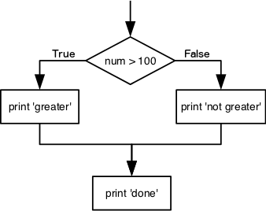

## `if-elif-else`

- We can chain tests together using `elif` (`else if`)

```python
if <condition1>:
    <executed if condition1 is True>
elif <condition2>:
    <executed if condition2 is True and condition1 is not True>
else:
    <executed if no conditions True>
```

```python
>>> num = -3
>>> if num > 0:
...     print(num, "is positive")
... elif num == 0:
...     print(num, "is zero")
... else:
...     print(num, "is negative")
...
-3 is negative
```

**LIVE DEMO**

## Combining conditions

Conditions can be combined using *Boolean Logic*

- Operators include `and`, `or` and `not`

```python
>>> if (4 > 0) or (2 > 0):
...     print('at least one part is true')
... else:
...     print('both parts are false')
...
at least one part is true
```

**LIVE DEMO**

## Exercise 07 (5min)

What is the result of executing the code below?

```python
>>> if 4 > 5:
...     print('A')
... elif 4 == 5:
...     print('B')
... elif 4 < 5:
...     print('C')
```

1. `A`
2. `B`
3. `C`
4. `B` and `C`

## More operators

Two useful condition operators are `==` (equality) and `in` (membership)

```python
>>> print(1 == 1)
True
>>> print(1 ==2)
False
>>> print('a' in 'toast')
True
>>> print('b' in 'toast')
False
>>> print(1 in [1, 2, 3])
True
>>> print(1 in range(3))
True
```

**LIVE DEMO**

## 08. Analysing multiple files

## Analysing multiple files

- We have several files of inflammation study data
  - We want to visualise/analyse each of them
  - We know how to load, visualise, loop over, and make decisions on the data

We will write a new script to do this:

- `analyse_files.py`

```bash
$ nano analyse_files.py
```

**BUT** we need to know how to interact with the filesystem to get filenames

## The `os` module

The `os` module allows interaction with the filesystem

```python
import matplotlib.pyplot
import numpy as np
import os
```

**LIVE DEMO**

## `os.listdir()`

The `os.listdir()` function lists the contents of a directory

- The list can be filtered with a `for` loop or *list comprehension*
- Our data is in the `data` directory

```python
# Get a list of inflammation data files
files = []
for fname in os.listdir('data'):
  if 'inflammation' in fname:
    files.append(fname)
print("Inflammation data files:", files)
```

```bash
$ python analyse_files.py
```

**BUT** something’s not quite right…

**LIVE DEMO**

## `os.path.join()`

- The `os.listdir()` function only returns filenames, not the *path* (relative or absolute)

`os.path.join()` builds a path from directory and filenames, suitable for the underlying OS

```python
files = []
for fname in os.listdir('data'):
  if 'inflammation' in fname:
    files.append(os.path.join('data', fname))
print("Inflammation data files:", files)
```

```bash
$ python analyse_files.py
Inflammation data files: ['data/inflammation-05.csv', …]
```

**LIVE DEMO**

## Visualising the data

Now we have all the tools we need to

- load all the inflammation data files
- visualise the mean, minimum and maximum values in an array of plots.
- list of paths to the data files with `os`
- load data from a file with `np.loadtxt()`
- calculate summary statistics with `np.mean()`, `np.max()`, etc.
- create figures with `matplotlib`
- create arrays of figures with `.add_subplot()`

## Visualisation code

We’re going to build the rest of this script together

```bash
$ nano analyse_files.py
$ python analyse_files.py
Analysing data/inflammation-05.csv
Writing image to data/inflammation-05.png
Analysing data/inflammation-11.csv
Writing image to data/inflammation-11.png
[…]
```

**LIVE DEMO**

## Checking Data

There are two suspicious features to some of the datasets

1. The maximum values rose and fell as straight lines
2. The minimum values are consistently zero

We’ll use `if` statements to test for these conditions and give a warning

## Suspicious maxima

Is day zero value 0, and day 20 value 20?

```bash
$ nano analyse_files.py
```

```python
    # Test for suspicious maxima
    if np.max(data, axis=0)[0] == 0 and np.max(data, axis=0)[20] == 20:
        print("Suspicious-looking maxima!")
```

```bash
$ python analyse_files.py
```

**LIVE DEMO**

## Suspicious minima

Are all the minima zero? (do they sum to zero?)

```bash
$ nano analyse_files.py
```

```python
    # Test for suspicious maxima
    if np.max(data, axis=0)[0] == 0 and np.max(data, axis=0)[20] == 20:
        print("Suspicious-looking maxima!")
    elif np.sum(data.min(axis=0)) == 0:
        print('Minima sum to zero!')
```

```bash
$ python analyse_files.py
```

**LIVE DEMO**

## Being tidy

If everything’s OK, let’s be reassuring

```bash
$ nano analyse_files.py
```

```python
    # Test for suspicious maxima
    if np.max(data, axis=0)[0] == 0 and np.max(data, axis=0)[20] == 20:
        print("Suspicious-looking maxima!")
    elif np.sum(data.min(axis=0)) == 0:
        print('Minima sum to zero!')
    else:
        print('Seems OK!')
```

```bash
$ python analyse_files.py
```

**LIVE DEMO**

## 09. Conclusions (Part 1)

## Learning Outcomes

- variables
- data types: `numpy.array`s, `list`s, `string`s, numbers
- file IO: loading data, listing files, manipulating filenames
- calculating statistics
- plotting data: plots and subplots
- program flow: loops and conditionals
- automating multiple analyses
- `Python` scripts: edit-save-execute

## Well done!

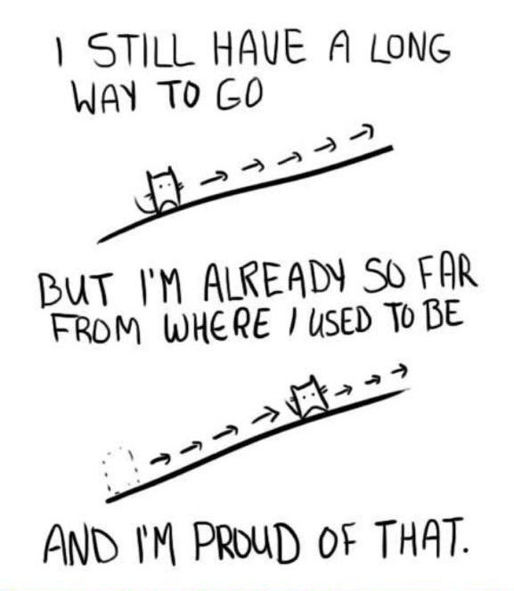

## Building Programs With `Python` (Part 2)

## Etherpad

Please do use the course Etherpad:

- http://pad.software-carpentry.org/2018-03-29-standrews
- **Communal notes**: share your understanding, and benefit from others
- **Ask questions**: get detailed answers with links and examples
- **A record/reference for after the course**

## Why are we here?

- **To learn basic concepts of programming** (in Python)
- **How to solve problems in your research by…**
  - Building scripts
  - Automating tasks
- **Good coding practice**
  - Functions
  - Defensive programming

## XKCD

[figure not shown]

## What are we doing?

Analysing experimental data

- Effectiveness of a new treatment for arthritis
- Several patients, recording inflammation on each day
- Tabular (comma-separated) data

We’re going to improve our code

- automation, reuse, sharing
- functions, documentation
- defensive programming

## Setting up

Before we begin…

**return to our neat working environment**

```bash
$ cd ~/Desktop
$ cd python-novice-inflammation
```

## 10. `Jupyter` notebooks

## Starting `Jupyter`

At the command-line, start `Jupyter` notebook:

```bash
jupyter notebook
```

**LIVE DEMO**

## `Jupyter` landing page

[figure not shown]

**LIVE DEMO**

## Create a new notebook

**LIVE DEMO**

## My first notebook

- Give your notebook a name (`functions`)

[figure not shown]

[figure not shown]

**LIVE DEMO**

## Cell types

`Jupyter` documents are comprised of *cells*

- A `Jupyter` cell can have one of several types

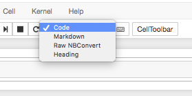

Change the first cell to `Markdown`

**LIVE DEMO**

## Markdown text

`Markdown` allows us to enter formatted text.

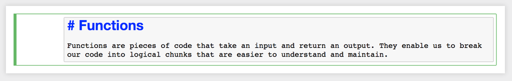

Execute a cell with `Shift + Enter`

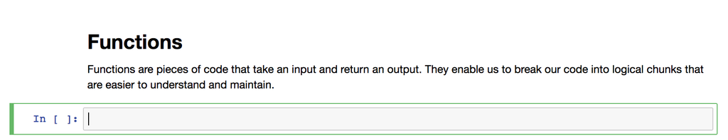

**LIVE DEMO**

## Entering code

`Python` code can be entered directly into a code cell

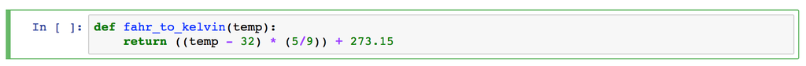

Execute a cell with `Shift + Enter`

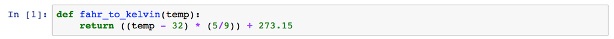

**LIVE DEMO**

## 11. Functions

## Motivation

- We have code to plot values of interest from multiple datasets

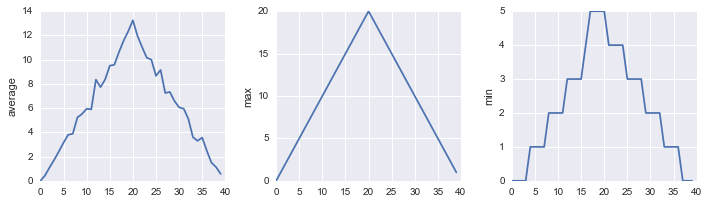

**BUT** the code is long and complicated

- It’s not flexible enough to deal with thousands of files
- We can’t modify it easily

**SO** we will package our code for reuse: **FUNCTIONS**

## What is a function?

Functions in code work like mathematical functions

\[y = f(x)\]

- \(f()\) is the function
- \(x\) is an input (or input*s*)
- \(y\) is the returned value, or output(s)
- The output \(y\) depends in some way on the value of \(x\) - defined by \(f()\).

**Not all functions in code take an input, or produce a usable output, but the principle is generally the same.**

## My first function

`fahr_to_kelvin()` to convert Fahrenheit to Kelvin

\[f(x) = ((x - 32) \times \frac{5}{9}) + 273.15\]

[figure not shown]

**LIVE DEMO**

## Calling the function

- Calling `fahr_to_kelvin()` in the notebook is the same as calling any other function

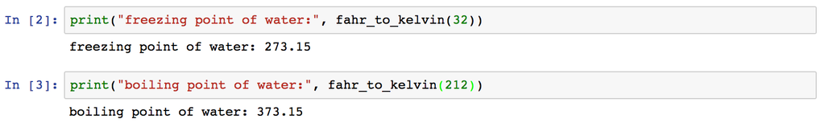

```python
print('freezing point of water:', fahr_to_kelvin(32))
print('boiling point of water:', fahr_to_kelvin(212))
```

**LIVE DEMO**

## Create a new function

Create a new function in your notebook, and call it.

```python
def kelvin_to_celsius(temp):
  return temp - 273.15
```

```python
print('freezing point of water', kelvin_to_celsius(273.15))
```

**LIVE DEMO**

## Composing functions

Composing `Python` functions works the same way as for mathematical functions: \(y = f(g(x))\)

- We could convert F (`temp_f`) to C (`temp_c`) by executing the code:

```python
temp_c = kelvin_to_celsius(fahr_to_kelvin(temp_f))
```

**LIVE DEMO**

## New functions from old

We can wrap this composed function inside a new function:

`fahr_to_celsius`:

```python
def fahr_to_celsius(temp_f):
    return kelvin_to_celsius(fahr_to_kelvin(temp_f))
print('freezing point of water in Celsius:', fahr_to_celsius(32.0))
```

**This is how programs are built:**

combining small bits into larger bits until the behaviour we want is obtained

**LIVE DEMO**

## Exercise 08 (10min)

Can you write a function called `outer()` that:

- takes a single `string` *argument*
- returns a string comprising only the first and last characters of the input, e.g.

```python
print(outer("helium"))
hm
```

## Function scope

Variables defined within a function, including parameters, are not ‘visible’ outside the function

- This is called *function scope*

```python
a = "Hello"

def my_fn(a):
  a = "Goodbye"

my_fn(a)
print(a)
```

**LIVE DEMO**

## Exercise 09 (5min)

What would be printed if you ran the code below?

```python
a, b = 3, 7

def swap(a, b):
    temp = a
    a = b
    b = temp

swap(a, b)
print(b, a)
```

1. `7 3`
2. `3 7`
3. `3 3`
4. `7 7`

## 12. Refactoring

## Tidying Up

Now we can write functions!

Let’s make the inflammation analysis easier to reuse: one function per operation

- Open the `analyse_files.py` notebook from the first lesson

**What operations should be put into functions?**

The code is divisible into two sections

1. check the data for problems
2. plot the data

## `detect_problems()`

- We noticed that some data was questionable
- This function spots problems with the data
  - Call the function after loading, before plotting

```python
def detect_problems(data):
    if np.max(data, axis=0)[0] == 0 and np.max(data, axis=0)[20] == 20:
        print('Suspicious looking maxima!')
    elif np.sum(data.min(axis=0)) == 0:
        print('Minima add up to zero!')
    else:
        print('Seems OK!')
```

**LIVE DEMO**

## `plot_data()`

We’ll write a function called `plot_data()` that plots the data to file

```python
def plot_data(data, fname):
    # create figure and three axes
    fig = plt.figure(figsize=(10.0, 3.0))
    [...]
```

**LIVE DEMO**

## Code reuse

Our code is now much more readable

- Loop over the files, load data, `detect_problems()` and `plot_data()`

```python
# Analyse each file in turn
for fname in files:
    print("Analysing", fname)

    # load data
    data = np.loadtxt(fname=fname, delimiter=',')

    # identify problems in the data
    detect_problems(data)

    # plot image in file
    imgname = fname[:-4] + '.png'
    plot_data(data, imgname)
```

## Good code pays off

Why should I bother?

- After 6 months, the referee report arrives and you need to rerun experiments
- Another student is continuing the project
- Some random person reads your article and asks for the code
- Helps spot errors quickly
- Clarifies structure in your mind as well as in the code
- Saves you time in the long run! (“Future You” will back this up)

## 13. Testing and documentation

## Motivation

- Once written, functions are reused
- Functions might be reused without further checks
- When functions are written:
  - test for correctness
  - document their function
- Example: centring a numerical array

## Create a new notebook

- Call it `testing`

## `centre()`

- Add the function

```python
import numpy as np

def centre(data, desired):
    return (data - np.mean(data)) + desired
```

**LIVE DEMO**

## Test datasets

- We could try `centre()` on real data
  - but we don’t know the answer!

Use `numpy` to create an artificial dataset

```python
z = np.zeros((2, 2))
print(centre(z, 3.0))
```

**LIVE DEMO**

## Real data

Try the function on real data…

```python
data = numpy.loadtxt(fname='data/inflammation-01.csv', delimiter=',')
print(centre(data, 0))
```

- But how do we know it worked?

**LIVE DEMO**

## Check properties

- We can check properties of the original and centred data
  - `mean`, `min`, `max`, `std`

```python
centred = centre(data, 0)
print('original min, mean, and max are:', numpy.min(data), numpy.mean(data), numpy.max(data))
print('min, mean, and max of centered data are:', numpy.min(centred),
      numpy.mean(centred), numpy.max(centred))
print('std dev before and after:', numpy.std(data), numpy.std(centred))
```

**LIVE DEMO**

## Documenting functions

- Writing comments in the code (using the hash `#`) is a good thing
- `Python` provides for *docstrings*
  - These go after the function definition
  - Hook into `Python`’s help system

```python
def centre(data, desired):
    """Returns the array in data, recentered around the desired value."""
    return (data - numpy.mean(data)) + desired

help(centre)
```

**LIVE DEMO**

## Default arguments

- The `centre()` function *requires* two arguments
- We can specify a *default* argument in how we define the function

```python
def centre(data, desired=0.0):
    """Returns the array in data, recentered around the desired value.

    Example: centre([1, 2, 3], 0) => [-1, 0, 1]
    """
    return (data - np.mean(data)) + desired
```

```python
centre(data, 0.0)
centre(data, desired=0.0)
centre(data)
```

**LIVE DEMO**

## Exercise 10 (10min)

Can you write a function called `rescale()` that - takes an array as input - returns an array with values scaled in the range [0.0, 1.0] - has an informative docstring

- **HINT:** If `L` and `H` are the lowest and highest values in the original array, then the replacement for a value `v` should be `(v-L) / (H-L)`.

## 14. Errors and Exceptions

## Create a new notebook

[figure not shown]

## Errors

> Programming *n.* - the process of making errors and correcting them until the code works
- **All** programmers make errors
- Identifying, fixing, and coping with errors is a valuable skill

## Traceback

`Python` tries to tell you what has gone wrong by providing a `traceback`

```python
def favourite_ice_cream():
    ice_creams = [
        "chocolate",
        "vanilla",
        "strawberry"
    ]
    print(ice_creams[3])
```

```python
favourite_ice_cream()
```

**LIVE DEMO**

## Anatomy of a traceback

```python
---------------------------------------------------------------------------
IndexError                                Traceback (most recent call last)
<ipython-input-1-b0e1f9b712d6> in <module>()
      8     print(ice_creams[3])
      9
---> 10 favourite_ice_cream()

<ipython-input-1-b0e1f9b712d6> in favourite_ice_cream()
      6         "strawberry"
      7     ]
----> 8     print(ice_creams[3])
      9
     10 favourite_ice_cream()

IndexError: list index out of range
```

- (mostly, you can just look at the last couple of levels)

**LIVE DEMO**

## Syntax errors

- *Logic* errors occur when the code is ‘correct’ but does something *illegal*
- *Syntax* errors occur when the code is not understandable as `Python`

```python
def some_function()
    msg = "hello, world!"
    print(msg)
     return msg
```

**LIVE DEMO**

## Syntax traceback

```python
  File "<ipython-input-3-dbf32ad5d3e8>", line 1
    def some_function()
                       ^
SyntaxError: invalid syntax
```

**LIVE DEMO**

## Fixed?

```python
def some_function():
    msg = "hello, world!"
    print(msg)
     return msg
```

**LIVE DEMO**

## Not quite

```python
  File "<ipython-input-4-e169556d667b>", line 4
    return msg
    ^
IndentationError: unexpected indent
```

**LIVE DEMO**

## Name errors

- `NameError`s occur when a variable is not defined in scope
  - (often due to a typo!)

```python
print(a)

---------------------------------------------------------------------------
NameError                                 Traceback (most recent call last)
<ipython-input-5-c5a4f3535135> in <module>()
----> 1 print(a)

NameError: name 'a' is not defined
```

**LIVE DEMO**

## Index Errors

- Trying to access an element of a collection that does not exist gives an `IndexError`

```python
letters = ['a', 'b']
print("Letter #1 is", letters[0])
print("Letter #2 is", letters[1])
print("Letter #3 is", letters[2])

Letter #1 is a
Letter #2 is b
---------------------------------------------------------------------------
IndexError                                Traceback (most recent call last)
<ipython-input-9-62bced7460d2> in <module>()
      2 print("Letter #1 is", letters[0])
      3 print("Letter #2 is", letters[1])
----> 4 print("Letter #3 is", letters[2])

IndexError: list index out of range
```

**LIVE DEMO**

## Exercise 11 (10min)

- Can you read the code below, and (without running it) identify what the errors are?
- Can you fix all the errors so the code prints `abbabbabba`?

```python
for number in range(10):
    # use a if the number is a multiple of 3, otherwise use b
    if (Number % 3) = 0:
        message = message + a
    else:
        message = message + "b"
print(message)
```